# PISA 2012 - Effects of Family Background and Economic Development of a Country on Student Achievement

## Investigation Overview

The purpose of this analysis is to investigate if parent background and whether the student’s coming from countries that are part of OECD *have an effect on students’ achievements. The main focus is on the* parent's highest education*,* wealth*,* cultural and home possessions*,* educational resources at home*,* single parenting*,* OECD country* in correlation with students' scores in mathematics, reading and science.

**OECD = Organisation for Economic Co-operation and Development*

## Dataset Overview

PISA 2012 is a survey of students' skills and knowledge as they approach the end of compulsory education. The original PISA 2012 dataset is very complex and contains 485490 rows and 636 columns. For the purpose of this analysis, I focused on only a few features, mentioned above. After cleaning the dataset contains 325497 rows and 19 columns. Some of those columns are part of feature engineering - new columns were made for more concise visualizations.

```python
# import all packages and set plots to be embedded inline
import numpy as np
import pandas as pd
import matplotlib.pyplot as plt
import seaborn as sns

%matplotlib inline

# suppress warnings from final output
import warnings
warnings.simplefilter("ignore")
```

```python
# load in the dataset into a pandas dataframe
df = pd.read_csv("Data/clean_PISA_df.csv")
```

```python
# load in the dataset into a pandas dataframe
# Define colors for consistency
colors = ['#7198cd','#cd853f']
color1 = ['#90b1c8']
color2 = ['#baae97']
color3 = ['#ad6d2f']
```

> Note that the above cells have been set as "Skip"-type slides. That means that when the notebook is rendered as http slides, those cells won't show up.

## Distribution of values for OECD Country, Gender and Single-Parents

The distribution of values for OECD countries and gender is pretty uniform. There are slightly more countries that joined OECD, that is 59.6% in comparison to countries that have not joined OECD 40.4%. Both genders are represented equally, 50,3% females and 49,7% males. 81.4% of students have two parents and 18.6% of students live in single-parent households.

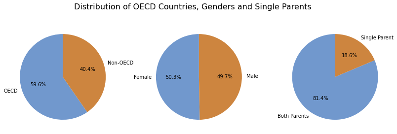

```python
# Plot pie charts for disribution
fig, (ax1, ax2, ax3) = plt.subplots(1,3, figsize=(14, 4))
ax1.pie(df['OECD_country'].value_counts(), colors = colors, labels=['OECD', 'Non-OECD'], autopct='%1.1f%%', startangle=90);
ax2.pie(df['Gender'].value_counts(), colors = colors, labels=['Female', 'Male'], autopct='%1.1f%%', startangle=90);
ax3.pie(df['Single_parent'].value_counts(), colors = colors, labels=['Both Parents', 'Single Parent'], autopct='%1.1f%%', startangle=90);
plt.suptitle('Distribution of OECD Countries, Genders and Single Parents', y=1.02, fontsize=16);
```

## Distribution of Mathematics, Reading, and Science Scores

Mathematics, reading, and science scores are normally distributed. The scores range from 0 to 1000 points. The main focus in this analysis is investigating certain features on students’ scores in general and not on separate scores on mathematics, reading, or science. For this reason, I calculated average scores and created a new single-column “overall scores” in the feature engineering section.

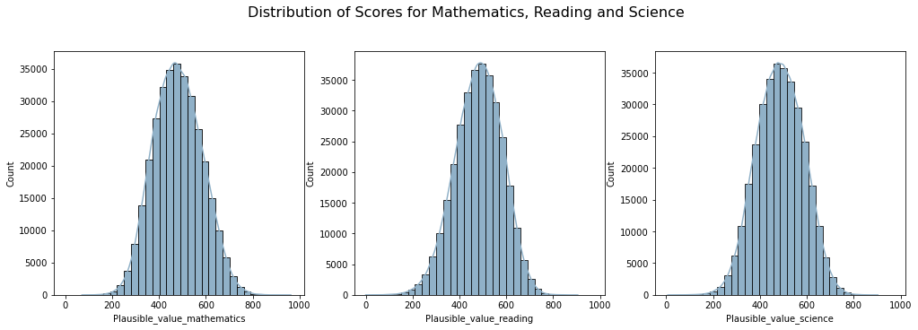

```python
# Plot the distribution of math, reading, science and overall scores
fig, axs = plt.subplots(ncols=3, figsize=(17, 5), sharex=True)
sns.histplot(df.Plausible_value_mathematics, kde=True, binwidth=30, ax=axs[0], color = color1, alpha=1);
sns.histplot(df.Plausible_value_reading, kde=True, binwidth=30, ax=axs[1], color = color1, alpha=1);
sns.histplot(df.Plausible_value_science, kde=True, binwidth=30, ax=axs[2], color = color1, alpha=1);
plt.suptitle('Distribution of Scores for Mathematics, Reading and Science', y=1.02, fontsize=16);
```

## Parent’s Highest Education Level and Students' Overall Scores

Based on this [wikipedia](https://en.wikipedia.org/wiki/International_Standard_Classification_of_Education) article I have adjusted the educational level of parents for better understanding and easier categorization:

| Pisa 2012 | From Wikipedia - ISCED 2011 | encoding used in this dataset |
| --- | --- | --- |
| ISCED 1 | Primary education | ISCED 1 |
| ISCED 2 | Lower secondary education | ISCED 2 |
| ISCED 3B, C | Upper secondary education | ISCED 3 |
| ISCED 3A, ISCED 4 | Post-secondary non-tertiary education | ISCED 4 |
| ISCED 5B | Short-cycle tertiary education | ISCED 5 |
| ISCED 5A, 6 | Bachelor's or equivalent | ISCED 6 |
| None | None | None |

The next chart clearly shows the distribution of overall students’ scores in each parents’ highest education category. There is a slightly positive trend in students’ overall scores. Students’ scores increase with parents’ educational level. An interesting observation from the chart is the large range of scores for parent’s educational level 4 (post-secondary non-tertiary education). The positive trend might not be as obvious from level to level, yet if we compare the first violin plot (ISCED 0) and last violin plot (ISCED 6) the difference is more distinct. The first violin plot is wider at the bottom, indicating a larger proportion of students received lower scores. From this visualization, I can conclude that parent’s education can have a positive impact on students’ scores.

```python
# Change Parent highest education to categorical datatype
educational_classes = ['ISCED 0','ISCED 1', 'ISCED 2', 'ISCED 3', 'ISCED 4', 'ISCED 5', 'ISCED 6']
vclasses = pd.api.types.CategoricalDtype(ordered = True, categories = educational_classes)
df['Parent_highest_education'] = df['Parent_highest_education'].astype(vclasses)
```

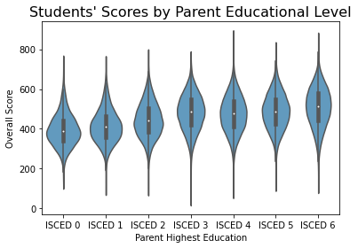

```python
default_color = sns.color_palette('Blues')[3]
# violin plots
sns.violinplot(data=df, x='Parent_highest_education', y='Overall_score', color = default_color);
plt.title("Students' Scores by Parent Educational Level", fontsize=16)
plt.ylabel('Overall Score')
plt.xlabel('Parent Highest Education');
```

### Parent’s Highest Education Level, Students' Overall Scores and OECD Countries

In addition to the previous slide, the next chart displays the same results with the addition of comparing students’ results whether they are coming from the country that is part of OECD or not. Although the chart has a lot of empty space at the bottom of the chart it is important to follow best practices to avoid misleading interpretations. Students’ results from OECD countries are slightly higher than from students from non-OECD countries. We can see a bigger gap between students whose parents have higher education (Level ISCED 4 - level ISCED 6). This observation could indicate that countries that invest in economical development can have a positive impact on students’ performance.

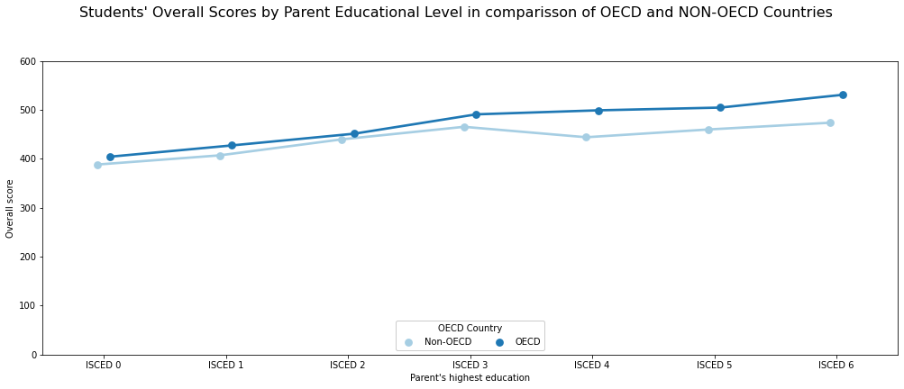

```python
# Plot dodged line plot
plt.figure(figsize = [17, 6])
ax = sns.pointplot(data = df,
                  x = 'Parent_highest_education', y = 'Overall_score', hue = 'OECD_country',
                  dodge = 0.1, palette = sns.color_palette('Paired')
                 )
ax.set_ylim(ymin=0)
ax.set_ylim(ymax=600)
ax.legend(loc = 8, ncol = 3, framealpha = 1, title = 'OECD Country');
plt.ylabel('Overall score')
plt.xlabel("Parent's highest education");

plt.suptitle("Students' Overall Scores by Parent Educational Level in comparisson of OECD and NON-OECD Countries", y=1.02, fontsize=16);
```

### Single Parents and Students' Overall Score

When comparing students’ results and parent educational level side by side with single parents and two-parent families we can see that students with single parents score slightly lower than students with both parents. However, we need to be a bit careful with this interpretation. At the beginning of this report, a pie chart with a ratio between single-parent and two-parent families shows that only 18.6% are single parents. This might cause uneven distribution of values.

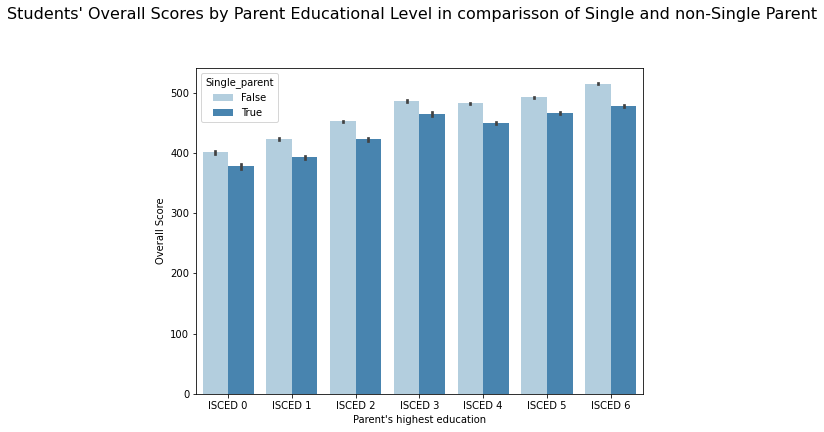

```python
# Plor error bar plot
fig = plt.figure(figsize = [8,6])
ax = sns.barplot(data = df, x = 'Parent_highest_education', y = 'Overall_score', hue = 'Single_parent',
           palette = 'Blues')

plt.ylabel('Overall Score')
plt.xlabel("Parent's highest education");

plt.suptitle("Students' Overall Scores by Parent Educational Level in comparisson of Single and non-Single Parent", y=1.02, fontsize=16);
plt.show();
```

### Correlation between Overall Score and Home Possessions

As PISA 2012 Technical report states “Collecting information about households' possessions of family wealth are believed to capture wealth better than income because they reflect a more stable source of wealth.” The image below shows the wording of items and their allocation for the following indices:

- WEALTH: Wealth
- CULTPOS : Cultural Possessions
- HEDRES: Home educational Resources
- HOMEPOS: Home Possessions

As mentioned at the beginning, the PISA 2012 dataset has many data points, and plotting correlations between variables with a large number of data points can lead to illegible plots. For this reason, I choose to plot 3 different scatter plots in order to highlight a correlation between home possessions and overall students’ scores.

The first plot contains 5% of all data points, so the correlation is a bit clearer. We could improve this with additional adjustments. In the second plot, I plotted a regression line that indicates a slight positive relationship between variables. In the third plot, I plotted variables in a 2D scatter plot or heat map with a clear distinction of where the majority of data points lie. From the charts, we can see that students that come from a household with a higher index of home possession tend to have slightly higher scores.

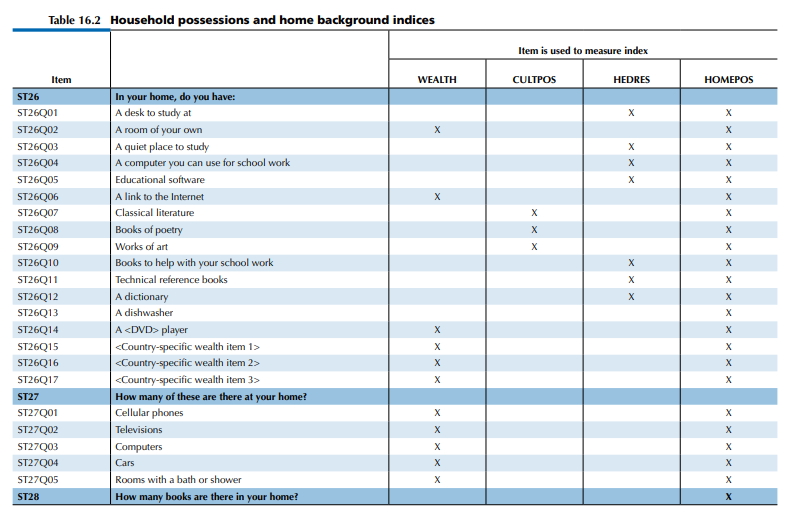

```python
from IPython import display
display.Image("Data/HomePossessionsIndicies.PNG", width=700)
```

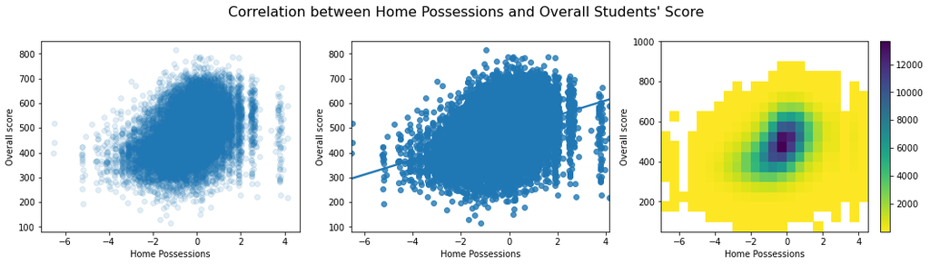

```python
# Change Parent highest education to categorical datatype
plt.figure(figsize = [18, 4])

# Scatter plot between scores and whealth and home possesions - sampling and transperancy
plt.subplot(1, 3, 1)
sample = df.sample(frac=0.05, replace=False, random_state=1)
plt.scatter(data = sample, y = 'Overall_score', x = 'Home_Possessions', alpha = 1/8);
plt.ylabel('Overall score')
plt.xlabel('Home Possessions')

# Scatter plot between overall scores and home possesions - regression line
ax = plt.subplot(1, 3, 2)
sample = df.sample(frac=0.05, replace=False, random_state=1)
sns.regplot(data = sample, y = 'Overall_score', x = 'Home_Possessions');
plt.ylabel('Overall score')
plt.xlabel('Home Possessions')

# Heat map between scores and whealth and home possesions
ax = plt.subplot(1, 3, 3)
bins_y = np.arange(50, 1000+50, 50)
bins_x = np.arange(-7, 4+1, 0.5)

plt.hist2d(data = df, y = 'Overall_score', x = 'Home_Possessions', cmap='viridis_r', cmin=0.5, bins = [bins_x, bins_y])
plt.colorbar()
plt.ylabel('Overall score')
plt.xlabel('Home Possessions');

plt.suptitle("Correlation between Home Possessions and Overall Students' Score", y=1.02, fontsize=16);
```

### Correlation between Home Possessions and Overall Students' Score Grouped by Parents' Highest Education

In addition to a previous slide, I wanted to show the correlation of students’ overall scores and home possessions grouped by parent highest education. From the heat map matrix, we can see a slight positive correlation amongst students’ overall score, home possessions, and parent education level. We can observe that darker spots move to the upper right corner as parents educational level increases.

```python
def hist2dgrid(x, y, **kwargs):
    """ Quick hack for creating heat maps with seaborn's PairGrid."""
    palette = kwargs.pop('color')
    plt.hist2d(x, y, cmap = palette, cmin = 0.5)
```

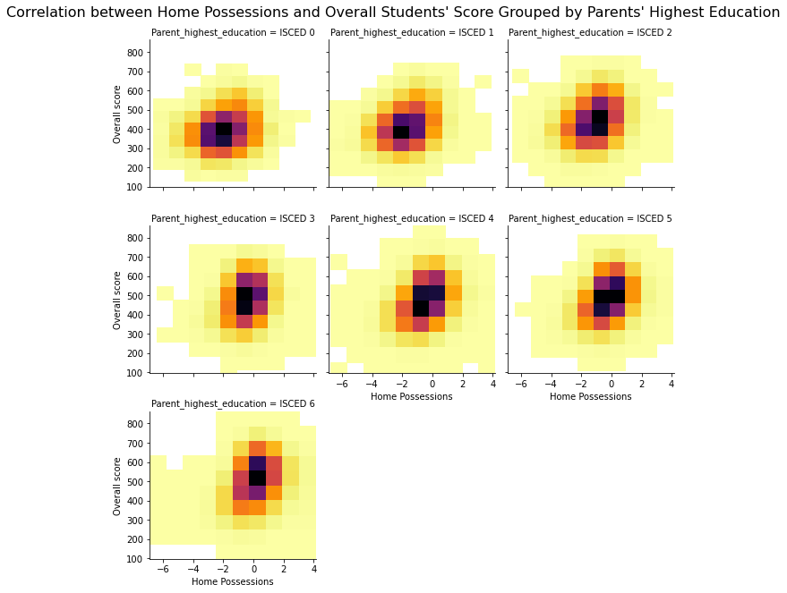

```python
# create faceted heat maps on levels of the cut variable
g = sns.FacetGrid(data = df, col = 'Parent_highest_education', col_wrap = 3, height = 3)
g.map(hist2dgrid, 'Home_Possessions', 'Overall_score', color = 'inferno_r')
g.set_xlabels('Home Possessions')
g.set_ylabels('Overall score')

plt.suptitle("Correlation between Home Possessions and Overall Students' Score Grouped by Parents' Highest Education", y=1.02, fontsize=16);
plt.show()
```

### Correlation Between Reading Score and Cultural Possessions

From the technical report of PISA 2012, we learned that cultural possession includes possessions of classical literature, books of poetry, and works of art. Cultural Possessions Index was grouped in 3 bins Low, Medium, and High due to discrete values of this variable. From the violin plots, we can see that students with a higher index of cultural possessions tend to score higher on reading tests.

```python
# Create bins for Cultural possessions based on descriptive statistics
bin_names = ['Low', 'Medium', 'High']
bin_edges = [-1.51, -0.48, 0.25, 1.27]
df['Cultural_Possessions_bin'] = pd.cut(df['Cultural_Possessions'], bin_edges, labels=bin_names)
```

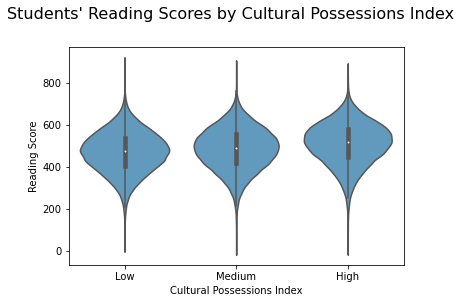

```python
# create faceted heat maps on levels of the cut variable
sns.violinplot(data=df, x='Cultural_Possessions_bin', y='Plausible_value_reading',color = default_color);

plt.ylabel('Reading Score')
plt.xlabel("Cultural Possessions Index");

plt.suptitle("Students' Reading Scores by Cultural Possessions Index", y=1.02, fontsize=16);
plt.show();
```

> Once you're ready to finish your presentation, check your output by using nbconvert to export the notebook and set up a server for the slides. From the terminal or command line, use the following expression:

> > `jupyter nbconvert <file_name>.ipynb --to slides --post serve --template output_toggle`

> This should open a tab in your web browser where you can scroll through your presentation. Sub-slides can be accessed by pressing 'down' when viewing its parent slide. Make sure you remove all of the quote-formatted guide notes like this one before you finish your presentation!